# RKM WEEK 13 IP Part 2

## 3.2 Bivariate Analysis

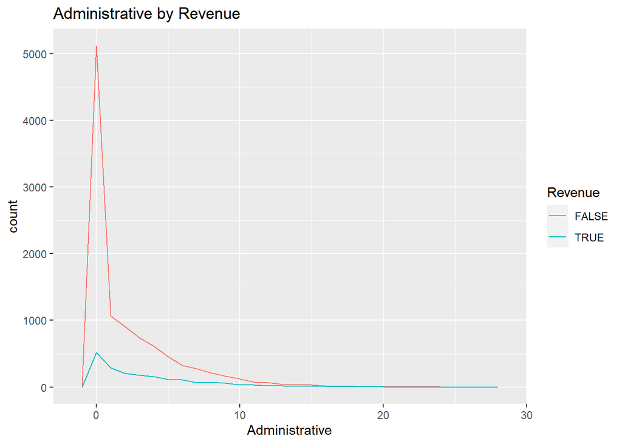

```r
# Administrative by Revenue
set_plot_dimensions(5, 4)
ggplot(cs_data, aes(x = Administrative, fill = Revenue, color = Revenue)) +
geom_freqpoly(binwidth = 1) +
labs(title = "Administrative by Revenue")
```

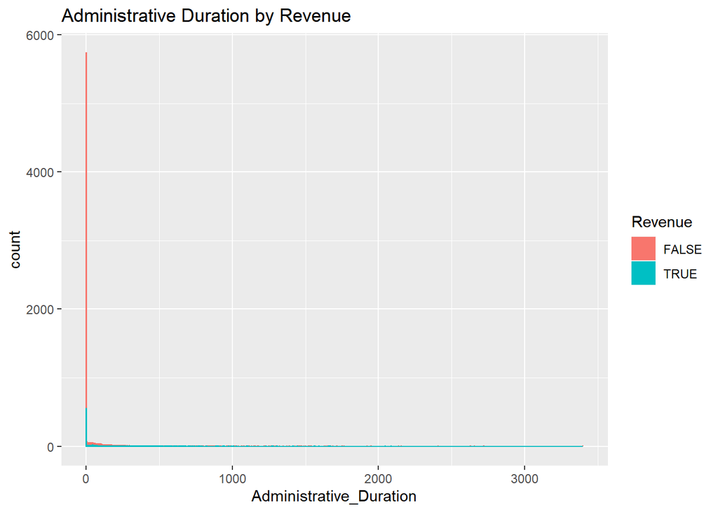

```r
# Administrative Duration by Revenue
set_plot_dimensions(5, 4)
ggplot(cs_data, aes(x = Administrative_Duration, fill = Revenue, color = Revenue)) +
geom_histogram(binwidth = 1) +
labs(title = "Administrative Duration by Revenue")
```

True revenue remains the same irrespective of administrative duration.

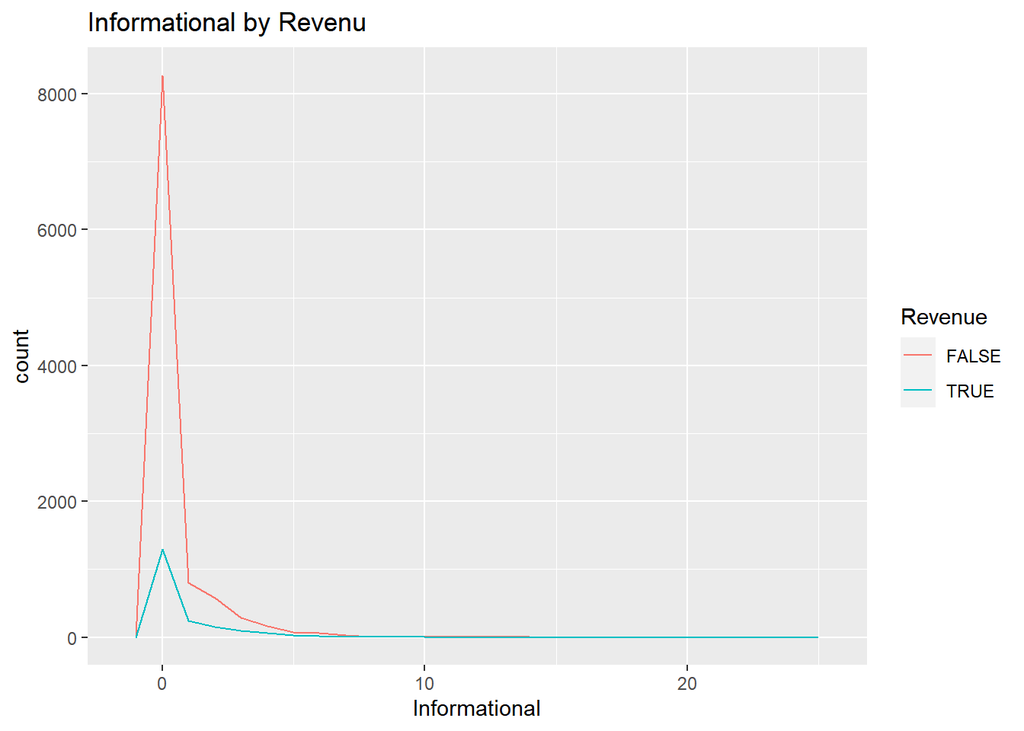

```r
# Informational by Revenue
set_plot_dimensions(5, 4)
ggplot(cs_data, aes(x = Informational, fill = Revenue, color = Revenue)) +
geom_freqpoly(binwidth = 1) +
labs(title = "Informational by Revenu")
```

True revenues increases slightly and eventually drops to zero, it remains zero irrespective of an increase in information.

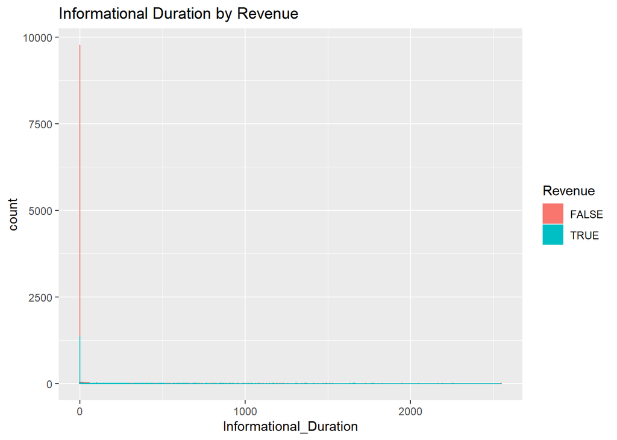

```r
# Informational Duration by Revenue
set_plot_dimensions(5, 4)
ggplot(cs_data, aes(x = Informational_Duration, fill = Revenue, color = Revenue)) +
geom_histogram(binwidth = 1) +
labs(title = "Informational Duration by Revenue")
```

True revenue remains the same irrespective of information duration.

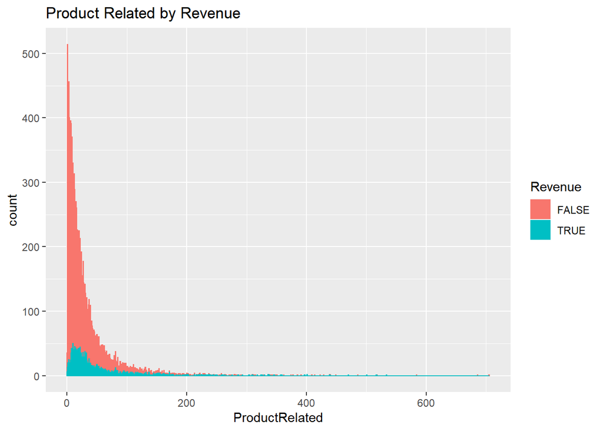

```r
# product related by Revenue
set_plot_dimensions(5, 4)
ggplot(cs_data, aes(x = ProductRelated, fill = Revenue, color = Revenue)) +
geom_histogram(binwidth = 1) +
labs(title = "Product Related by Revenue")
```

true revenue remains low despite the product related increasing.

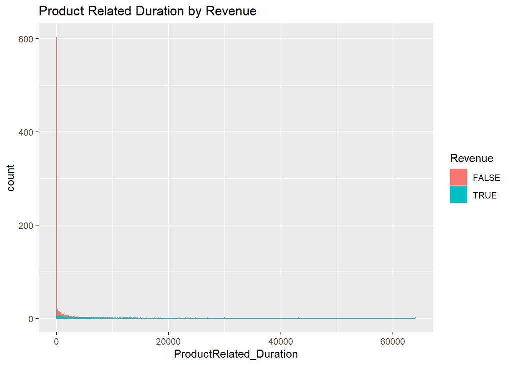

```r
# product related duration by Revenue
set_plot_dimensions(5, 4)
ggplot(cs_data, aes(x = ProductRelated_Duration, fill = Revenue, color = Revenue)) +
geom_histogram(binwidth = 1) +
labs(title = "Product Related Duration by Revenue")
```

true revenue remains low despite the product related duration increasing.

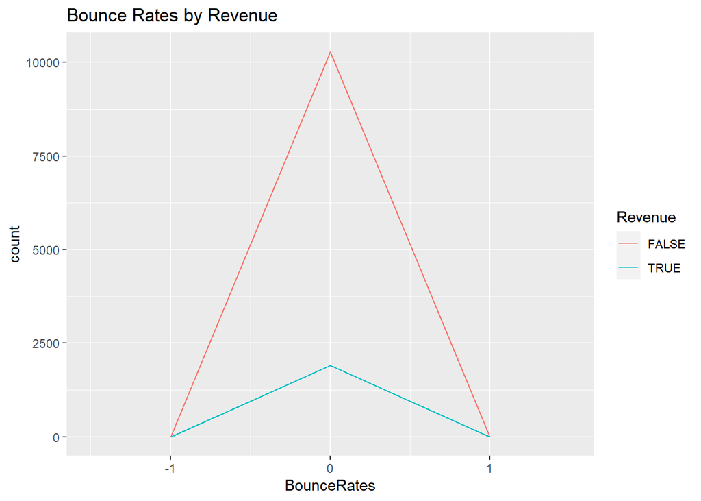

```r
# bounce rates by Revenue
set_plot_dimensions(5, 4)
ggplot(cs_data, aes(x = BounceRates, fill = Revenue, color = Revenue)) +
geom_freqpoly(binwidth = 1) +
labs(title = "Bounce Rates by Revenue")
```

bounce rates increases false revenue sharply fron negative to 0 then drop sharply to 1. true revenue also does the same but at lower rate compared to false positive.

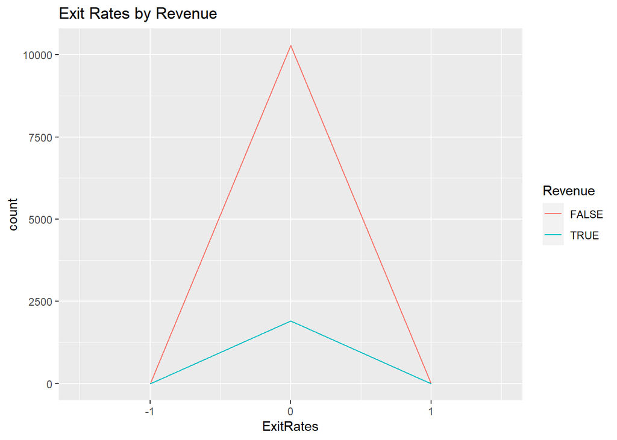

```r
# exit rates by Revenue
set_plot_dimensions(5, 4)
ggplot(cs_data, aes(x = ExitRates, fill = Revenue, color = Revenue)) +
geom_freqpoly(binwidth = 1) +
labs(title = "Exit Rates by Revenue")
```

exit rates increases false revenue sharply from negative to 0 then drop sharply to 1. true revenue also does the same but at lower rate compared to false positive.

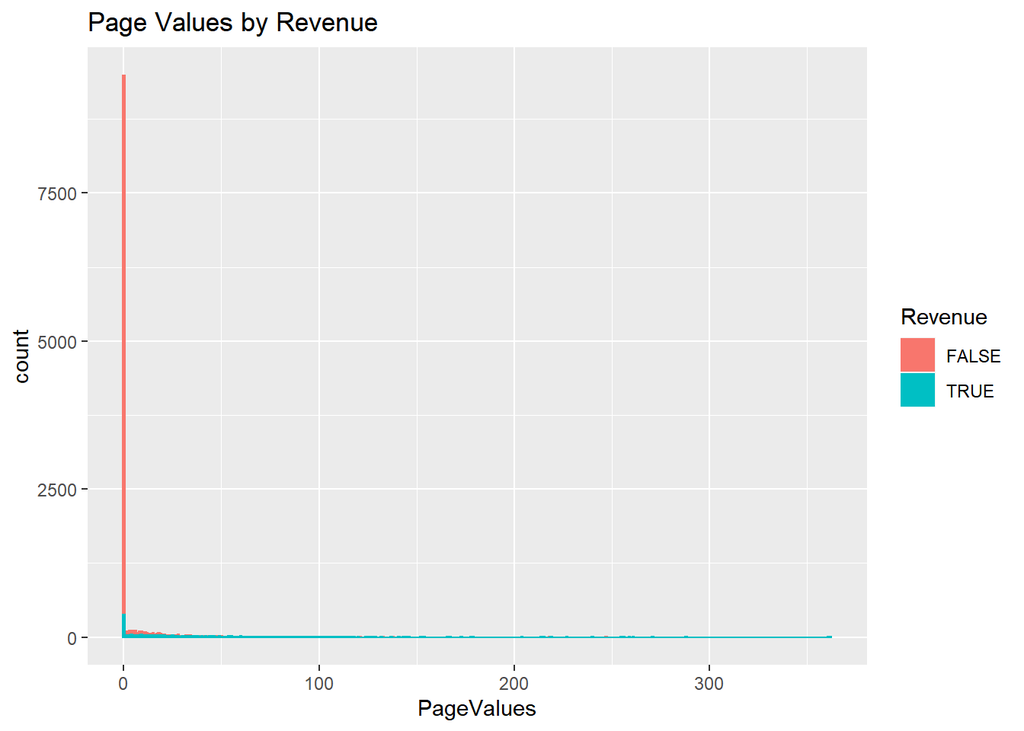

```r
# Page Values by Revenue
set_plot_dimensions(5, 4)
ggplot(cs_data, aes(x = PageValues, fill = Revenue, color = Revenue)) +
geom_histogram(binwidth = 1) +
labs(title = "Page Values by Revenue")
```

true revenue remains low despite the page values increasing.

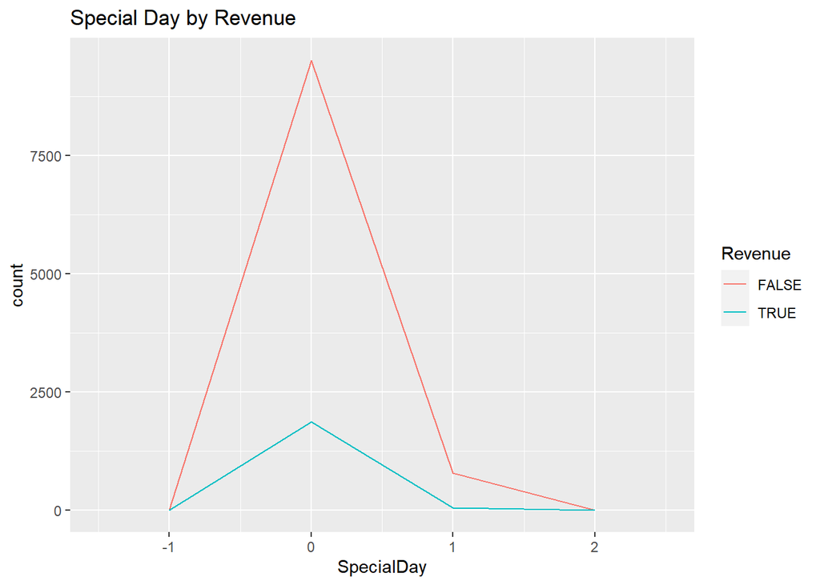

```r
# special day by Revenue
set_plot_dimensions(5, 4)
ggplot(cs_data, aes(x = SpecialDay, fill = Revenue, color = Revenue)) +
geom_freqpoly(binwidth = 1) +
labs(title = "Special Day by Revenue")
```

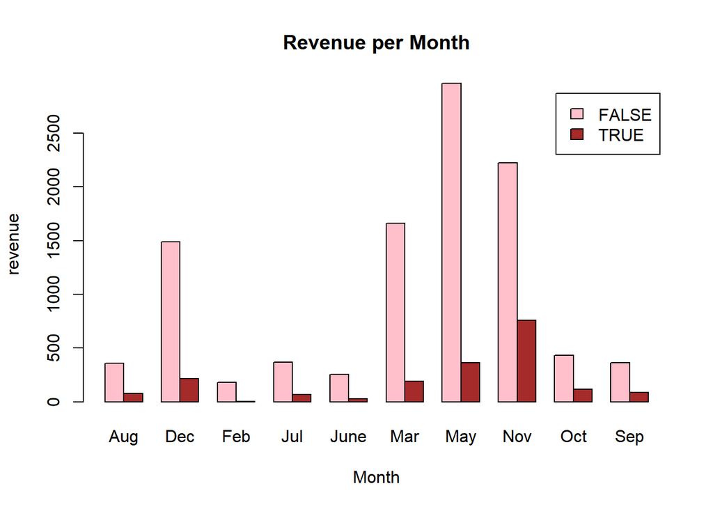

```r
# plotting the distribution of Revenue per Month
set_plot_dimensions(6, 6)
rev_month <- table(cs_data$Revenue, cs_data$Month)
barplot(rev_month, main = "Revenue per Month", col = c("pink", "brown"), beside = TRUE,
legend = rownames(rev_month), ylab="revenue", xlab = "Month")
```

observation: November returns the highest number of revenues while February returns the lowest.

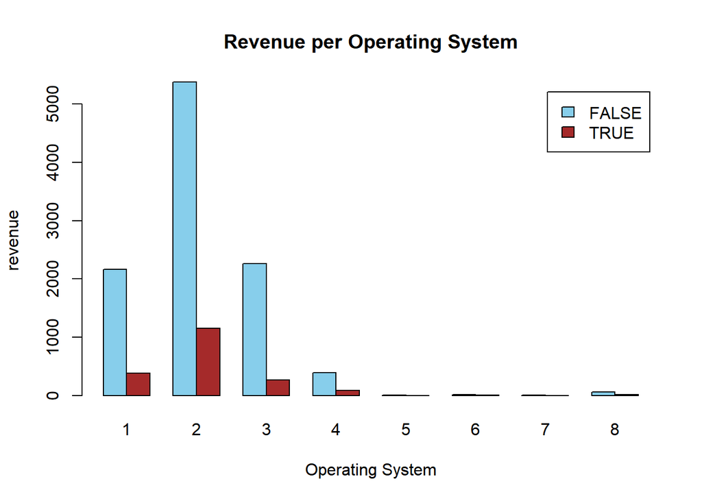

```r
# plotting the distribution of Revenue per Operating System
set_plot_dimensions(6, 6)
rev_os <- table(cs_data$Revenue, cs_data$OperatingSystems)
barplot(rev_os, main = "Revenue per Operating System", col = c("sky blue", "brown"), beside = TRUE,
        legend = rownames(rev_os),ylab="revenue", xlab = "Operating System")
```

observation: Operating System 2 returns the highest number of revenue while OS 5, 6, and 7 return the lowest.

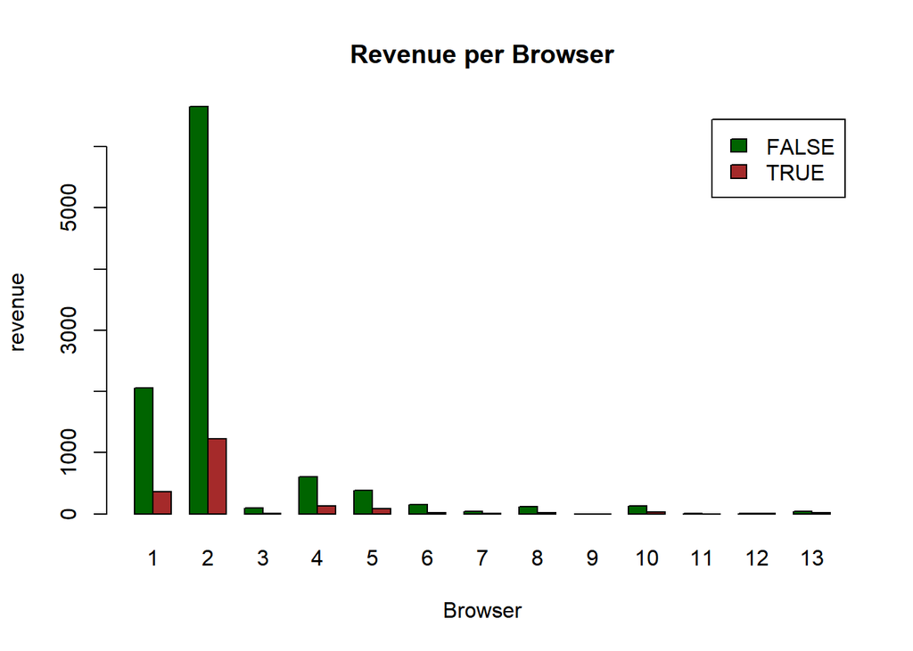

```r
# plotting the distribution of Revenue per Browser
set_plot_dimensions(6, 6)
rev_browser <- table(cs_data$Revenue, cs_data$Browser)
barplot(rev_browser, main = "Revenue per Browser", col = c("dark green", "brown"), beside = TRUE,
        legend = rownames(rev_browser),ylab="revenue", xlab = "Browser")
```

observation: browser 2 returns the highest number of revenue while 3, 7, 9, 11, and 12 return the lowest.

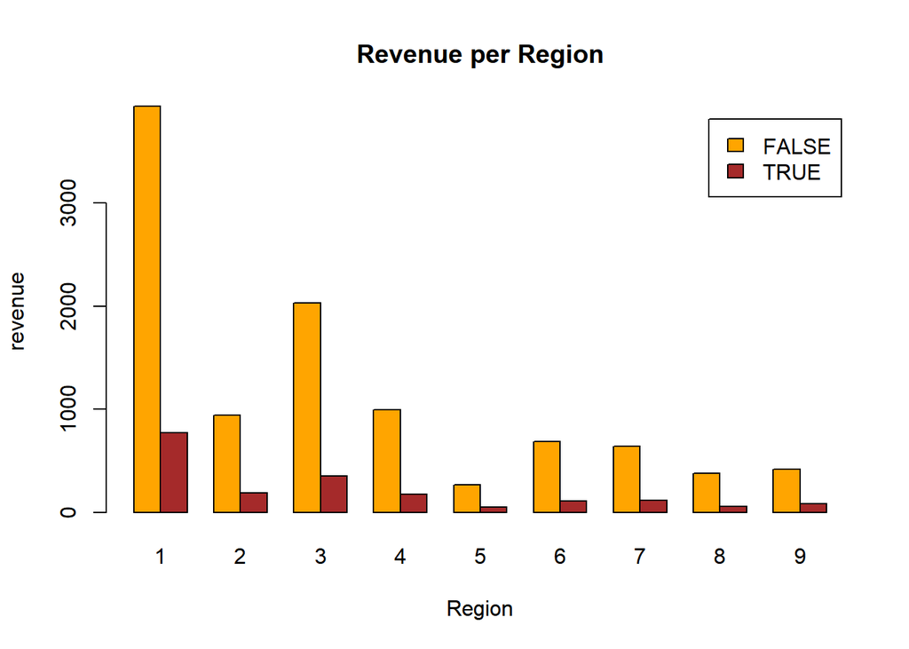

```r
# plotting the distribution of Revenue per Region
set_plot_dimensions(6, 6)
rev_region <- table(cs_data$Revenue, cs_data$Region)
barplot(rev_region, main = "Revenue per Region", col = c("orange", "brown"), beside = TRUE,
        legend = rownames(rev_region), ylab="revenue", xlab = "Region")
```

observation: region 1 returns the highest number of revenue, Region 5 and 8 returns the lowest.

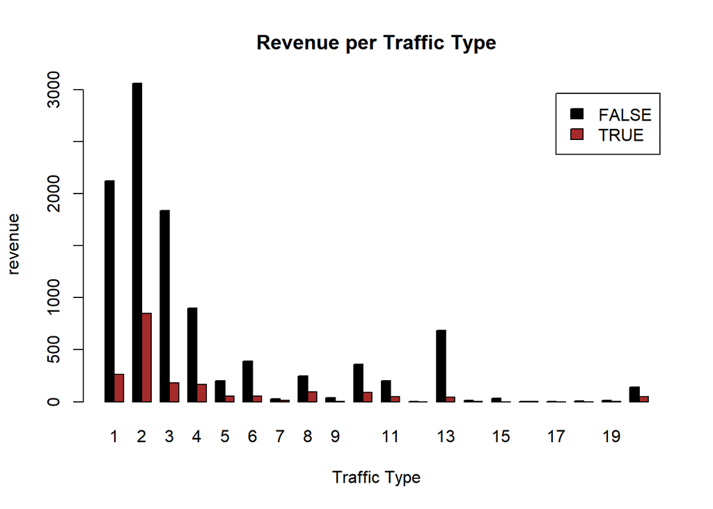

```r
# plotting the distribution of Revenue per Traffic Type
set_plot_dimensions(6,6)
rev_traffic <- table(cs_data$Revenue, cs_data$TrafficType)
barplot(rev_traffic, main = "Revenue per Traffic Type", col = c("black", "brown"), beside = TRUE,
        legend = rownames(rev_traffic), ylab="revenue", xlab = "Traffic Type")
```

observation: Traffic 2 has the highest number of revenues, 12, 14, 16, 17, and 18 return the lowest.

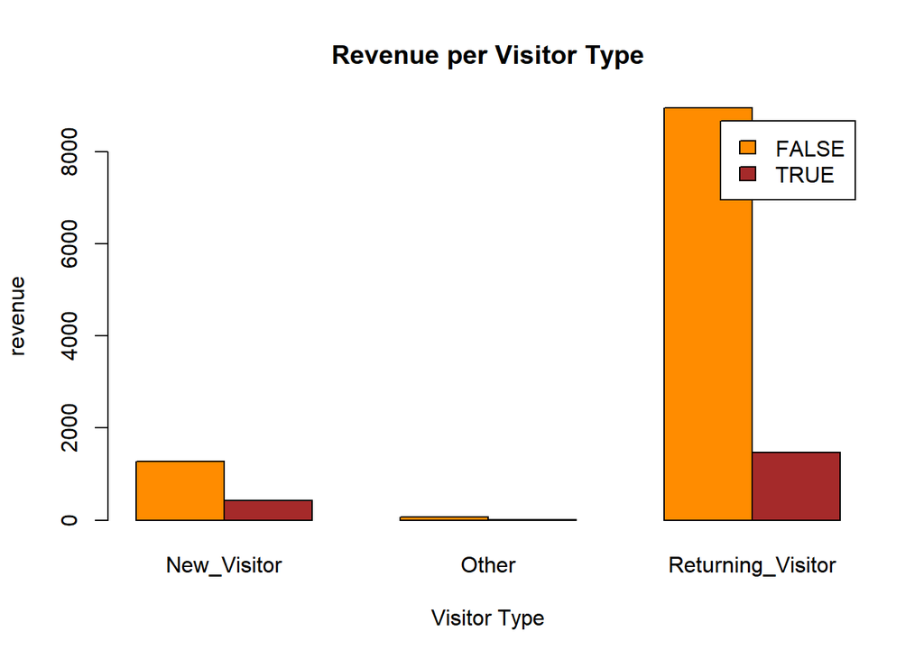

```r
# plotting the distribution of Revenue per Visitor Type
set_plot_dimensions(6, 6)
rev_visitor <- table(cs_data$Revenue, cs_data$VisitorType)
barplot(rev_visitor, main = "Revenue per Visitor Type", col = c("dark orange", "brown"), beside = TRUE,
        legend = rownames(rev_visitor), ylab="revenue", xlab = "Visitor Type")
```

observation; returning visitors generated more revenue.

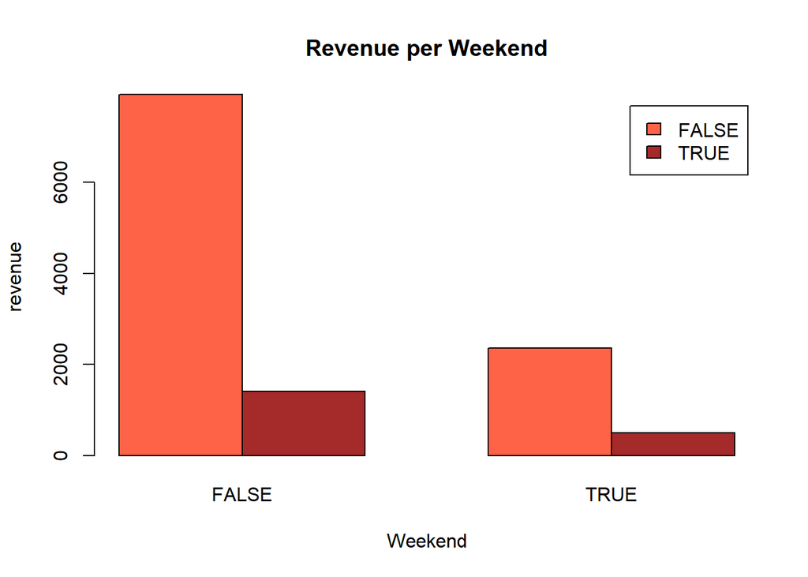

```r
# plotting the distribution of Revenue per Weekend
set_plot_dimensions(6, 6)
rev_weekend <- table(cs_data$Revenue, cs_data$Weekend)
barplot(rev_weekend, main = "Revenue per Weekend", col = c("tomato", "brown"), beside = TRUE,
        legend = rownames(rev_weekend),ylab="revenue", xlab = "Weekend")
```

observation: more revenue was generated during the weekdays than the weekends. This is to be expected since there are way more records of weekdays than of weekends.

### plotting correlation of the numerical variables..

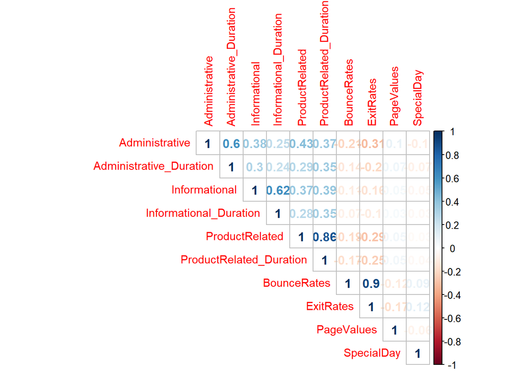

```r
#install.packages("corrplot")
library(corrplot)
## Let’s build a correlation matrix to understand the relation between each attributes
corrplot(cor(cs_num), type = 'upper', method = 'number', tl.cex = 0.9)
```

observation: There is a strong linear correlation between a couple of variables.

1. BounceRates and ExitRates are highly positive correlation of 0.9.
2. Administrative and Administrative_Duration have a high positive correlation of 0.6.
3. Informational and Informational_Duration high positive correlated of 0.62,
4. ProductRelated and ProductRated_Duration have high positive correlation of 0.86.

Therefore, we will have to drop one variable of each of the highly correlated pairs to reduce dimensionality and redundancy.

## We can model the relationship between these variables by fitting a linear equation

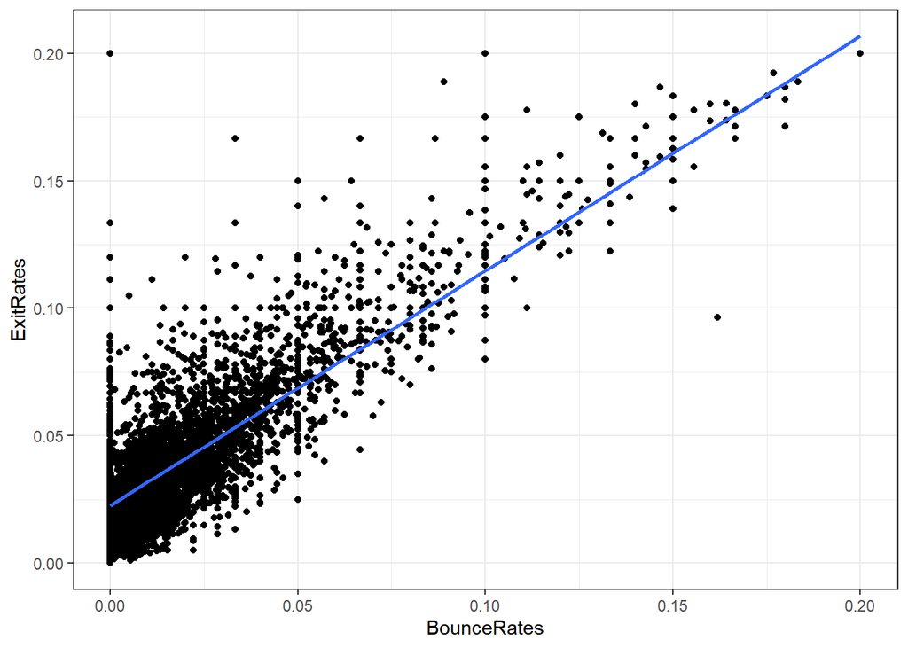

```r
# Relationship between "BounceRates" and "ExitRates"
#

ggplot(cs_num, aes(x = BounceRates, y =ExitRates)) +
  geom_point() +
  geom_smooth(method = 'lm', se = FALSE) +
  theme_bw()
```

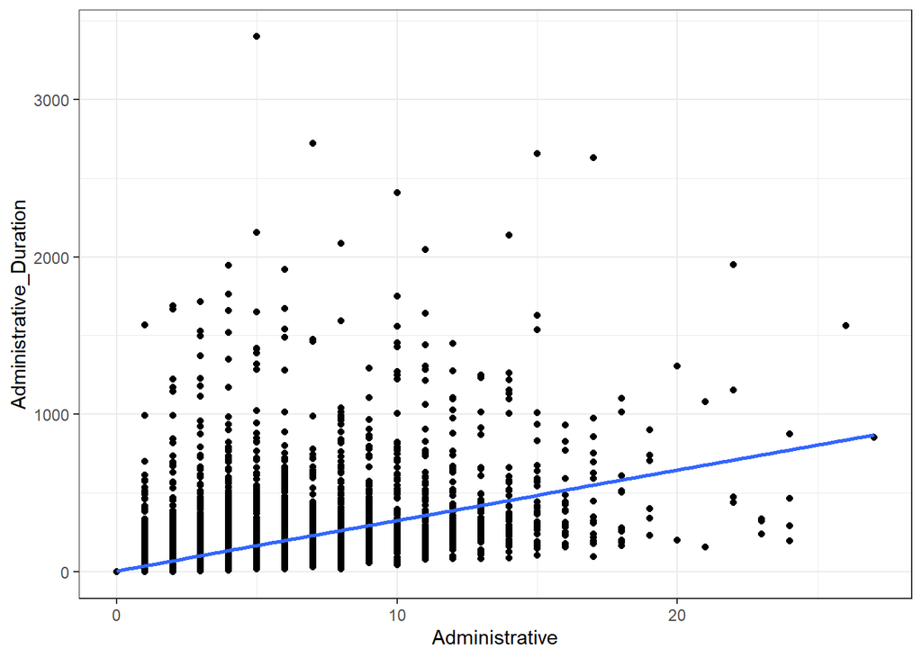

```r
# Relationship between "Administrative" and "Administrative_Duration"
#

ggplot(cs_num, aes(x = Administrative, y =Administrative_Duration)) +
  geom_point() +
  geom_smooth(method = 'lm', se = FALSE) +
  theme_bw()
```

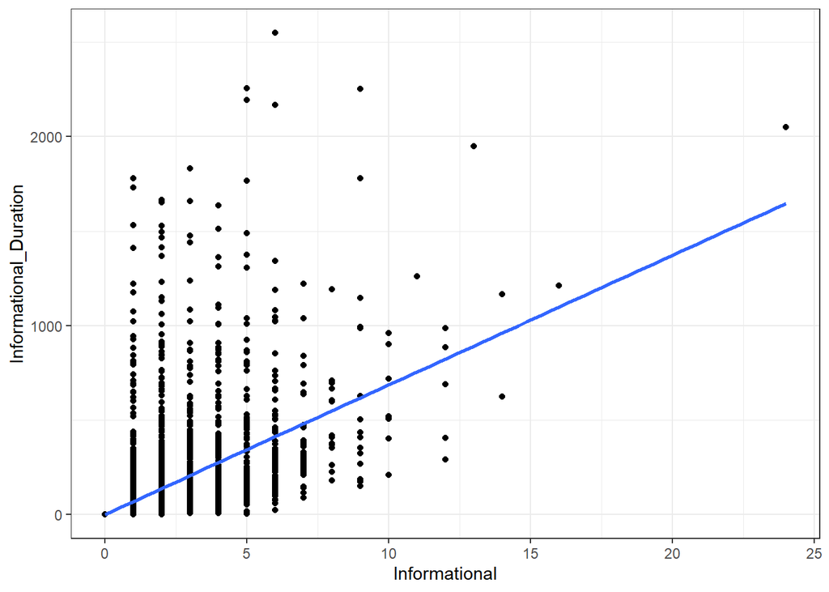

```r
# Relationship between "Informational" and "Informational_Duration"
#

ggplot(cs_num, aes(x = Informational, y =Informational_Duration)) +
  geom_point() +
  geom_smooth(method = 'lm', se = FALSE) +
  theme_bw()
```

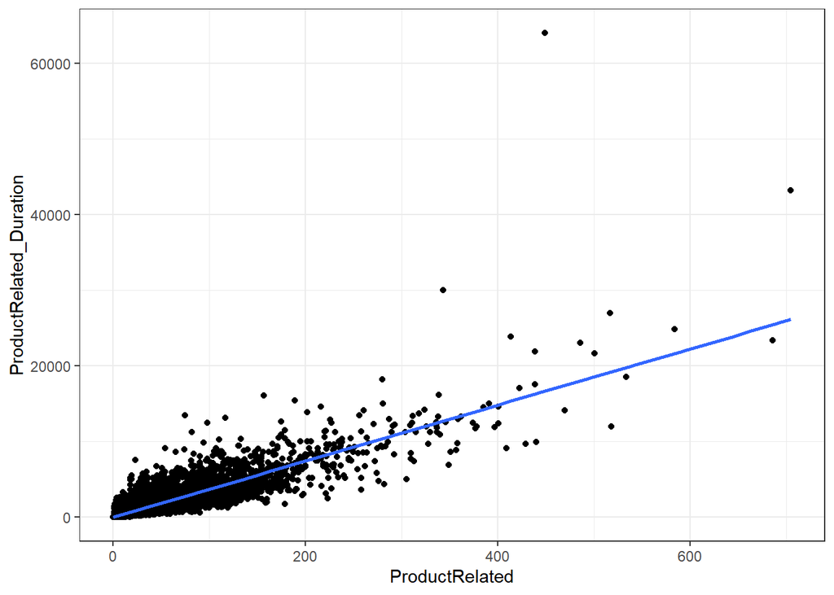

```r
# Relationship between "ProductRelated" and "ProductRated_Duration"
#

ggplot(cs_num, aes(x = ProductRelated, y = ProductRelated_Duration
)) +
  geom_point() +
  geom_smooth(method = 'lm', se = FALSE) +
  theme_bw()
```

observation: from the 4 scatter plots above, there is a high positive correlation between the pairs, Therefore, we will have to drop one variable of each of the highly correlated pairs to reduce dimensionality and redundancy.

## dropping the highly correlated columns

```r
# selecting highly correlated columns to be dropped
to_drop <- c("Administrative_Duration", "Informational_Duration", "ProductRelated_Duration", "ExitRates")
#
#dropping the highly correlated colunms
#
cs_data <- cs_data[, !names(cs_data) %in% to_drop]
head(cs_data)
```

```
## # A tibble: 6 x 14
##   Administrative Informational ProductRelated BounceRates PageValues SpecialDay
##            <int>         <int>          <int>       <dbl>      <dbl>      <dbl>
## 1              0             0              1      0.2             0          0
## 2              0             0              2      0               0          0
## 3              0             0              1      0.2             0          0
## 4              0             0              2      0.05            0          0
## 5              0             0             10      0.02            0          0
## 6              0             0             19      0.0158          0          0
## # ... with 8 more variables: Month <fct>, OperatingSystems <fct>,
## #   Browser <fct>, Region <fct>, TrafficType <fct>, VisitorType <fct>,
## #   Weekend <fct>, Revenue <fct>
```

### numerical colunms for after dropping highly correlated colunms

```r
# getting the numerical columns from the new and revised dataframe
new_num <- cs_data[,1:6]
head(new_num)
```

```
## # A tibble: 6 x 6
##   Administrative Informational ProductRelated BounceRates PageValues SpecialDay
##            <int>         <int>          <int>       <dbl>      <dbl>      <dbl>
## 1              0             0              1      0.2             0          0
## 2              0             0              2      0               0          0
## 3              0             0              1      0.2             0          0
## 4              0             0              2      0.05            0          0
## 5              0             0             10      0.02            0          0
## 6              0             0             19      0.0158          0          0
```

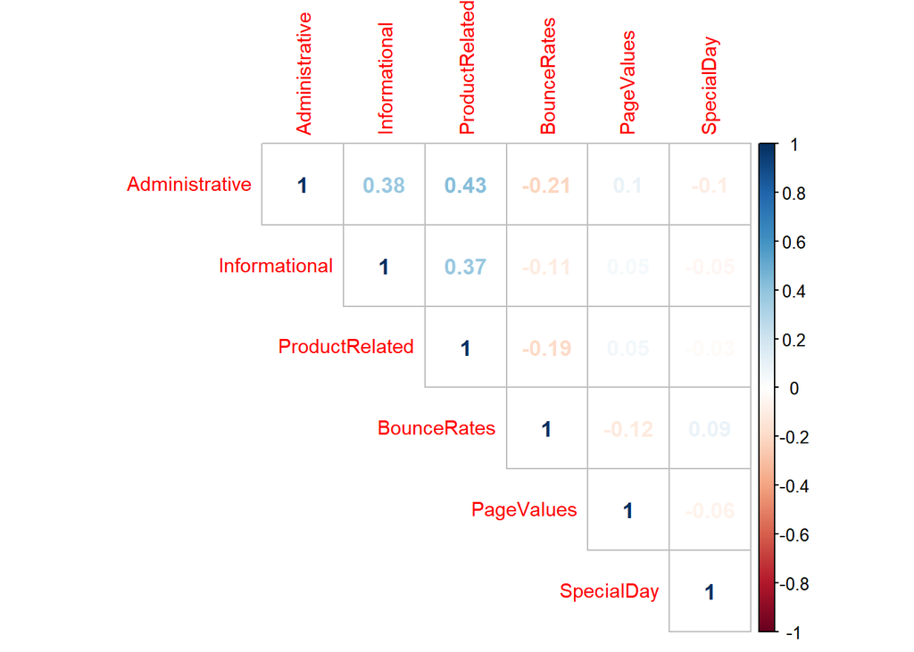

```r
## Let’s build a correlation matrix to understand the relation between each attributes
corrplot(cor(new_num), type = 'upper', method = 'number', tl.cex = 0.9)
```

observation: As we can see, removing the highly correlated variables has reduced multicollinearity in our dataset. It also made it easier to proceed with the modelling.

##saving our new dataset

```r
# save to csv
write.csv(new_num, "customer_new.csv")
```

##. Modeling

## Unsupervised Learning

Unsupervised learning requires data that has no labels. So we will create a new dataset that does not have the “Revenue” column.

## prieveing the dataset to be used

```r
#previewing the dataset
head(cs_data)
```

```
## # A tibble: 6 x 14
##   Administrative Informational ProductRelated BounceRates PageValues SpecialDay
##            <int>         <int>          <int>       <dbl>      <dbl>      <dbl>
## 1              0             0              1      0.2             0          0
## 2              0             0              2      0               0          0
## 3              0             0              1      0.2             0          0
## 4              0             0              2      0.05            0          0
## 5              0             0             10      0.02            0          0
## 6              0             0             19      0.0158          0          0
## # ... with 8 more variables: Month <fct>, OperatingSystems <fct>,
## #   Browser <fct>, Region <fct>, TrafficType <fct>, VisitorType <fct>,
## #   Weekend <fct>, Revenue <fct>
```

## removing the target/label variable “Revenue”

```r
cs_new <- cs_data[, -14]
cs_new.revenue <- cs_data[, "Revenue"]
head(cs_new)
```

```
## # A tibble: 6 x 13
##   Administrative Informational ProductRelated BounceRates PageValues SpecialDay
##            <int>         <int>          <int>       <dbl>      <dbl>      <dbl>
## 1              0             0              1      0.2             0          0
## 2              0             0              2      0               0          0
## 3              0             0              1      0.2             0          0
## 4              0             0              2      0.05            0          0
## 5              0             0             10      0.02            0          0
## 6              0             0             19      0.0158          0          0
## # ... with 7 more variables: Month <fct>, OperatingSystems <fct>,
## #   Browser <fct>, Region <fct>, TrafficType <fct>, VisitorType <fct>,
## #   Weekend <fct>
```

observation;the dataset to be used contains 13 colunms, this is after dropping the target variable.

```r
# Previewing the revenue column
# ---
#
head(cs_new.revenue)
```

```
## # A tibble: 6 x 1
##   Revenue
##   <fct>
## 1 FALSE
## 2 FALSE
## 3 FALSE
## 4 FALSE
## 5 FALSE
## 6 FALSE
```

observation: this is the removed target variable.

## converting factors to numerical for modeling

```r
# convert the factors into numerics
cs_new$Month <- as.numeric(cs_new$Month)
cs_new$OperatingSystems <- as.numeric(cs_new$OperatingSystems)
cs_new$Browser <- as.numeric(cs_new$Browser)
cs_new$Region <- as.numeric(cs_new$Region)
cs_new$TrafficType <- as.numeric(cs_new$TrafficType)
cs_new$VisitorType <- as.numeric(cs_new$VisitorType)
cs_new$Weekend <- as.numeric(cs_new$Weekend)
```

```r
## checking the new datatypes
#
str(cs_new)
```

```
## tibble [12,199 x 13] (S3: tbl_df/tbl/data.frame)
##  $ Administrative  : int [1:12199] 0 0 0 0 0 0 0 1 0 0 ...
##  $ Informational   : int [1:12199] 0 0 0 0 0 0 0 0 0 0 ...
##  $ ProductRelated  : int [1:12199] 1 2 1 2 10 19 1 1 2 3 ...
##  $ BounceRates     : num [1:12199] 0.2 0 0.2 0.05 0.02 ...
##  $ PageValues      : num [1:12199] 0 0 0 0 0 0 0 0 0 0 ...
##  $ SpecialDay      : num [1:12199] 0 0 0 0 0 0 0.4 0 0.8 0.4 ...
##  $ Month           : num [1:12199] 3 3 3 3 3 3 3 3 3 3 ...
##  $ OperatingSystems: num [1:12199] 1 2 4 3 3 2 2 1 2 2 ...
##  $ Browser         : num [1:12199] 1 2 1 2 3 2 4 2 2 4 ...
##  $ Region          : num [1:12199] 1 1 9 2 1 1 3 1 2 1 ...
##  $ TrafficType     : num [1:12199] 1 2 3 4 4 3 3 5 3 2 ...
##  $ VisitorType     : num [1:12199] 3 3 3 3 3 3 3 3 3 3 ...
##  $ Weekend         : num [1:12199] 1 1 1 1 2 1 1 2 1 1 ...
##  - attr(*, "na.action")= 'omit' Named int [1:14] 1066 1133 1134 1135 1136 1137 1474 1475 1476 1477 ...
##   ..- attr(*, "names")= chr [1:14] "1066" "1133" "1134" "1135" ...
```

observation: now our dataset all datatypes are numerical and integers.

```r
# checking for missing values
anyNA(cs_new)
```

```
## [1] FALSE
```

```r
# dataset summary
#
summary(cs_new)
```

```
##  Administrative  Informational     ProductRelated    BounceRates
##  Min.   : 0.00   Min.   : 0.0000   Min.   :  0.00   Min.   :0.00000
##  1st Qu.: 0.00   1st Qu.: 0.0000   1st Qu.:  8.00   1st Qu.:0.00000
##  Median : 1.00   Median : 0.0000   Median : 18.00   Median :0.00293
##  Mean   : 2.34   Mean   : 0.5088   Mean   : 32.06   Mean   :0.02045
##  3rd Qu.: 4.00   3rd Qu.: 0.0000   3rd Qu.: 38.00   3rd Qu.:0.01667
##  Max.   :27.00   Max.   :24.0000   Max.   :705.00   Max.   :0.20000
##    PageValues        SpecialDay          Month        OperatingSystems
##  Min.   :  0.000   Min.   :0.00000   Min.   : 1.000   Min.   :1.000
##  1st Qu.:  0.000   1st Qu.:0.00000   1st Qu.: 6.000   1st Qu.:2.000
##  Median :  0.000   Median :0.00000   Median : 7.000   Median :2.000
##  Mean   :  5.952   Mean   :0.06197   Mean   : 6.168   Mean   :2.124
##  3rd Qu.:  0.000   3rd Qu.:0.00000   3rd Qu.: 8.000   3rd Qu.:3.000
##  Max.   :361.764   Max.   :1.00000   Max.   :10.000   Max.   :8.000
##     Browser           Region       TrafficType      VisitorType
##  Min.   : 1.000   Min.   :1.000   Min.   : 1.000   Min.   :1.000
##  1st Qu.: 2.000   1st Qu.:1.000   1st Qu.: 2.000   1st Qu.:3.000
##  Median : 2.000   Median :3.000   Median : 2.000   Median :3.000
##  Mean   : 2.358   Mean   :3.153   Mean   : 4.075   Mean   :2.716
##  3rd Qu.: 2.000   3rd Qu.:4.000   3rd Qu.: 4.000   3rd Qu.:3.000
##  Max.   :13.000   Max.   :9.000   Max.   :20.000   Max.   :3.000
##     Weekend
##  Min.   :1.000
##  1st Qu.:1.000
##  Median :1.000
##  Mean   :1.234
##  3rd Qu.:1.000
##  Max.   :2.000
```

observation. the above gives as an overview of our dataset, it show our datapoints are on different scales.

## preparing our data for K-means clustering

let’s prepare our data to do the K means clustering

From the data summary, we have seen that there are variables who are on a different scale, we need to either scale the data or normalise it. We can normalise the data using the mean and standard deviation, also we can use scale function to normalise our data.

```r
# normalizing our dataset by use of scale function.
#
library(dplyr)
cs_norm <- as.data.frame(scale(cs_new))
#
#previewing the scaled dataset.
head(cs_norm)
```

```
##   Administrative Informational ProductRelated  BounceRates PageValues
## 1     -0.7025315    -0.3988128     -0.6963635  3.954699721 -0.3190356
## 2     -0.7025315    -0.3988128     -0.6739424 -0.450343788 -0.3190356
## 3     -0.7025315    -0.3988128     -0.6963635  3.954699721 -0.3190356
## 4     -0.7025315    -0.3988128     -0.6739424  0.650917089 -0.3190356
## 5     -0.7025315    -0.3988128     -0.4945739 -0.009839437 -0.3190356
## 6     -0.7025315    -0.3988128     -0.2927843 -0.102577188 -0.3190356
##   SpecialDay     Month OperatingSystems    Browser     Region TrafficType
## 1 -0.3103105 -1.333953       -1.2396607 -0.7939682 -0.8962939 -0.76562243
## 2 -0.3103105 -1.333953       -0.1371074 -0.2093703 -0.8962939 -0.51660683
## 3 -0.3103105 -1.333953        2.0679992 -0.7939682  2.4336556 -0.26759123
## 4 -0.3103105 -1.333953        0.9654459 -0.2093703 -0.4800502 -0.01857564
## 5 -0.3103105 -1.333953        0.9654459  0.3752276 -0.8962939 -0.01857564
## 6 -0.3103105 -1.333953       -0.1371074 -0.2093703 -0.8962939 -0.26759123
##   VisitorType    Weekend
## 1    0.409771 -0.5528638
## 2    0.409771 -0.5528638
## 3    0.409771 -0.5528638
## 4    0.409771 -0.5528638
## 5    0.409771  1.8086156
## 6    0.409771 -0.5528638
```

observation: our data is now scaled and is now on the same scale.

** Computing k-means clustering in R **

```r
set.seed(123)

cs.newk7 <- kmeans(cs_norm, centers = 7, nstart = 20)
print(cs.newk7)
```

```
## K-means clustering with 7 clusters of sizes 931, 675, 4299, 1672, 1871, 1129, 1622
##
## Cluster means:
##   Administrative Informational ProductRelated BounceRates   PageValues
## 1    -0.37296277    -0.2093847    -0.11334354   0.1006824 -0.224186879
## 2    -0.69319120    -0.3930067    -0.67052116   3.7281786 -0.319035624
## 3    -0.20439364    -0.2226877    -0.14096360  -0.1874604 -0.062071805
## 4    -0.14481955    -0.2028599    -0.13939043  -0.2320146  0.021282281
## 5    -0.10529361    -0.1135239    -0.07088646  -0.2156894 -0.005720033
## 6     1.78302172     1.9692832     1.80470745  -0.3103087  0.191850307
## 7     0.07394066    -0.1567107    -0.31300751  -0.4084723  0.277085654
##     SpecialDay       Month OperatingSystems     Browser      Region TrafficType
## 1  3.171634556  0.26532058       0.04526982  0.01417090 -0.09823269  0.18470240
## 2  0.004218715 -0.09255934       0.08503666 -0.01190611  0.04410851  0.29463065
## 3 -0.281657728 -0.02576796      -0.03169932 -0.16095976 -0.49079761 -0.05228745
```

[output cut: 362 more lines]

## checking the records in clusters

```r
# # previewing the number of records in each cluster
cs.newk7$cluster
```

```
##     [1] 2 3 2 3 5 3 2 2 1 1 3 1 3 3 3 4 2 5 3 4 1 2 3 1 2 4 3 3 3 3 4 5 3 3 3 4
##    [37] 5 1 1 3 4 1 3 1 3 3 3 3 3 2 2 3 1 3 1 2 2 3 4 1 1 3 6 5 2 1 3 2 4 2 2 4
##    [73] 1 3 3 3 3 1 1 2 5 1 3 3 2 2 3 3 1 3 3 2 3 7 1 3 3 1 1 3 3 1 1 1 3 2 1 3
##   [109] 1 6 1 2 2 3 3 5 1 3 3 4 4 1 1 3 3 2 3 4 1 2 5 3 2 1 1 3 4 3 1 3 2 4 3 2
##   [145] 3 1 3 3 3 1 3 2 4 3 3 5 2 1 2 1 5 5 1 1 3 3 3 4 1 1 3 1 2 1 3 4 3 1 5 2
##   [181] 2 1 6 3 3 6 4 3 2 6 3 3 5 3 7 3 7 7 5 5 7 3 3 7 7 7 7 3 3 4 4 5 3 3 4 3
##   [217] 3 3 4 3 3 7 3 5 3 3 3 3 5 3 5 5 5 6 5 5 5 3 3 3 4 5 4 3 4 3 6 5 5 3 2 3
##   [253] 5 3 3 4 3 7 5 2 5 3 4 5 4 3 3 5 5 2 7 3 5 4 5 4 3 3 5 5 6 3 4 3 2 3 6 3
##   [289] 4 3 3 2 3 3 3 3 2 3 5 5 2 4 3 3 5 3 3 5 3 5 3 3 6 3 3 3 3 3 4 3 4 7 4 3
##   [325] 7 5 3 7 2 7 3 3 3 3 3 3 3 3 3 2 3 4 2 7 3 3 7 5 7 4 5 4 3 3 2 3 3 2 3 5
##   [361] 3 3 5 7 5 4 3 5 3 4 7 6 3 3 4 5 4 3 3 3 4 2 6 3 3 4 3 3 3 4 5 3 5 3 7 3
##   [397] 2 6 3 3 7 4 7 4 7 3 6 4 4 5 7 5 5 3 5 5 4 5 2 3 5 6 5 2 4 3 2 3 5 3 7 5
##   [433] 7 3 3 3 4 5 3 3 7 3 5 3 7 3 5 3 7 4 5 7 5 7 2 3 7 3 5 3 3 5 3 4 2 5 4 3
##   [469] 4 5 3 7 7 3 6 2 3 3 4 7 4 3 4 5 3 5 5 3 4 7 5 5 5 5 3 3 3 6 3 3 7 3 3 3
##   [505] 3 6 3 5 4 2 3 5 3 5 3 3 5 5 3 4 5 4 3 3 3 4 2 5 5 3 3 3 3 3 2 4 7 5 6 7
```

[output cut: 324 more lines]

### checking clusters

```r
# previewing the cluster centers
cs.newk7$centers
```

```
##   Administrative Informational ProductRelated BounceRates   PageValues
## 1    -0.37296277    -0.2093847    -0.11334354   0.1006824 -0.224186879
## 2    -0.69319120    -0.3930067    -0.67052116   3.7281786 -0.319035624
## 3    -0.20439364    -0.2226877    -0.14096360  -0.1874604 -0.062071805
## 4    -0.14481955    -0.2028599    -0.13939043  -0.2320146  0.021282281
## 5    -0.10529361    -0.1135239    -0.07088646  -0.2156894 -0.005720033
## 6     1.78302172     1.9692832     1.80470745  -0.3103087  0.191850307
## 7     0.07394066    -0.1567107    -0.31300751  -0.4084723  0.277085654
##     SpecialDay       Month OperatingSystems     Browser      Region TrafficType
## 1  3.171634556  0.26532058       0.04526982  0.01417090 -0.09823269  0.18470240
## 2  0.004218715 -0.09255934       0.08503666 -0.01190611  0.04410851  0.29463065
## 3 -0.281657728 -0.02576796      -0.03169932 -0.16095976 -0.49079761 -0.05228745
## 4 -0.262993221 -0.15358097       0.15567588  0.65948482  1.43711048  0.07033723
## 5 -0.310310494  0.04450174      -0.01925030 -0.11375995 -0.04356163 -0.01697853
## 6 -0.237574596  0.15864666      -0.00429320 -0.11254141 -0.20206284 -0.11187377
## 7 -0.281291931 -0.04891916      -0.11263644 -0.04682180  0.04833805 -0.06509335
##   VisitorType     Weekend
## 1   0.3137528 -0.15717012
## 2   0.2687929 -0.13654370
## 3   0.4060818 -0.55286376
## 4   0.3554440 -0.51190509
## 5   0.4074592  1.80861560
## 6   0.3842294 -0.09688281
## 7  -2.4720950  0.12122067
```

observation; these are the 7 clusters data point distribution.

```r
# Cluster size
cs.newk7$size
```

```
## [1]  931  675 4299 1672 1871 1129 1622
```

```r
# Between clusters sum of square
cs.newk7$betweenss
```

```
## [1] 59208.1
```

this shows some of square. between clusters.

```r
# Within cluster sum of square
cs.newk7$withinss
```

```
## [1]  6949.579  5672.773 22257.998 18174.604 13032.406 17689.578 15588.958
```

observation: this is sum of squares with the cluster.

```r
# Total with sum of square
cs.newk7$tot.withinss
```

```
## [1] 99365.9
```

This is the total number of the sum of squares within the cluster.

```r
# Total sum of square
cs.newk7$totss
```

```
## [1] 158574
```

this is the total sum of all squares.

```r
cs.newk7 <- kmeans(cs_norm, centers = 2, nstart = 20)
cs.newk7 <- kmeans(cs_norm, centers = 3, nstart = 20)
cs.newk7 <- kmeans(cs_norm, centers = 4, nstart = 20)
cs.newk7 <- kmeans(cs_norm, centers = 5, nstart = 20)
cs.newk7 <- kmeans(cs_norm, centers = 6, nstart = 20)
```

```r
# Compute k-means clustering with k = 3, optimal cluster
set.seed(123)
final <- kmeans(cs_norm, centers = 3, nstart = 25)
print(final)
```

```
## K-means clustering with 3 clusters of sizes 8564, 1742, 1893
##
## Cluster means:
##   Administrative Informational ProductRelated BounceRates PageValues
## 1    -0.34106429    -0.2749808     -0.2307625   0.1363908 -0.1149003
## 2     0.04871678    -0.1639393     -0.3236744  -0.3400093  0.3185973
## 3     1.49815634     1.3948854      1.3418334  -0.3041495  0.2266295
##    SpecialDay       Month OperatingSystems      Browser       Region
## 1  0.08025934 -0.01555918      -0.01119696 -0.003081778 -0.005190229
## 2 -0.21372987 -0.08281177       0.06732698  0.124541821  0.118748122
## 3 -0.16641500  0.14659637      -0.01130102 -0.100665347 -0.085795091
##   TrafficType VisitorType     Weekend
## 1  0.01463032   0.4055620 -0.03280887
## 2  0.04946766  -2.4200735  0.09918651
## 3 -0.11170984   0.3922528  0.05715388
```

[output cut: 350 more lines]

```r
# showing how the clusters respond to the revenue variable
table(final$cluster, cs_data$Revenue)
```

```
##
##     FALSE TRUE
##   1  7614  950
##   2  1301  441
##   3  1376  517
```

this is how the 3 clusters responds to the revenue variable that was dropped.

### We can extract the clusters and add to our initial data to do some descriptive statistics at the cluster level

```r
cs_norm %>%
  mutate(Cluster = final$cluster) %>%
  group_by(Cluster) %>%
  summarize_all('median')
```

```
## # A tibble: 3 x 14
##   Cluster Administrative Informational ProductRelated BounceRates PageValues
##     <int>          <dbl>         <dbl>          <dbl>       <dbl>      <dbl>
## 1       1         -0.703        -0.399         -0.382      -0.329     -0.319
## 2       2         -0.102        -0.399         -0.427      -0.450     -0.319
## 3       3          1.40          1.17           0.851      -0.355     -0.223
## # ... with 8 more variables: SpecialDay <dbl>, Month <dbl>,
## #   OperatingSystems <dbl>, Browser <dbl>, Region <dbl>, TrafficType <dbl>,
## #   VisitorType <dbl>, Weekend <dbl>
```

these are median of variables in our clusters.

## Hierarchical clustering

```r
# Before hierarchical clustering, we can compute some descriptive statistics
# ---
#
desc_ <- data.frame(
  Min = apply(cs_norm, 2, min),
  Med = apply(cs_norm, 2, median),
  Mean = apply(cs_norm, 2, mean),
  SD = apply(cs_norm, 2, sd),
  Max = apply(cs_norm, 2, max)
)
desc_ <- round(desc_, 1)
head(desc_)
```

```
##                 Min  Med Mean SD  Max
## Administrative -0.7 -0.4    0  1  7.4
## Informational  -0.4 -0.4    0  1 18.4
## ProductRelated -0.7 -0.3    0  1 15.1
## BounceRates    -0.5 -0.4    0  1  4.0
## PageValues     -0.3 -0.3    0  1 19.1
## SpecialDay     -0.3 -0.3    0  1  4.7
```

observation: the variable has low mean and variance since they are already standardized.

### Agglomerative Nesting (Hierarchical Clustering) using euclidean

we will use the rescaled dataset cs_norm for hierarchical clustering.

```r
library(cluster)
# First we use the dist() function to compute the Euclidean distance between observations,
# res.hc will be the first argument in the hclust() function dissimilarity matrix
# ---
# first we compute the euclidean distance using euclidean metric
# eucl_dist(cs_norm, method = "euclidean")
```

```r
# checking euclidean distance in matrix form
#as.matrix(eucl_dist)[1:6, 1:6]
```

```r
# then we compute hierarchical clustering using the Ward method
#hcl_ <- hclust(eucl_dist, method =  "ward.D2")
#hcl_
```

```r
# Lastly, we plot the obtained dendrogram
# ---
#
#plot(hcl_, cex = 0.6, hang = -1)
```

```r
# Cut tree into 60 groups
#grp <- cutree(hcl_, k = 10)
#head(grp, n = 10)
```

```r
# Number of data points in each cluster
#table(grp)
```

### Agglomerative (Hierarchical Clustering) using manhattan method

```r
# We now use the R function hclust() for hierarchical clustering
# ---
#

# First we use the dist() function to compute the Euclidean distance between observations,
# d will be the first argument in the hclust() function dissimilarity matrix
# ---
# first we compute the manhattan distance using manhattan metric
#
#man_dist <-dist(cs_norm,method= "manhattan")
```

```r
#
#as.matrix(man_distance)[1:6, 1:6]
```

```r
# We then hierarchical clustering using the Ward's method
# ---
#
#man_hc <- hclust(man_dist)
#man_hc
```

```r
# Lastly, we plot the obtained dendrogram
# ---
#
#plot(man_hc, cex = 0.6, hang = -1)
```

```r
### Enhanced Visualization of Dendrogram

# Cut the tree

#library(factoextra)
#library("ggplot2")

##fviz_dend(man_hc, cex = 0.5, k = 10,color_labels_by_k = TRUE)
```

```r
# Cut tree into 25 groups
#grp <- cutree(man_hc, k = 10)
#head(grp, n = 10)
```

```r
# Number of data points in each cluster
#table(grp)
```